# Counties

Steve Simon and Satya Golla

12/29/2021

The important counties for this program are

Cass County, MO (29037) Clay County, MO (29047) Jackson County, MO (29095) Johnson County, KS (20091) Leavenworth County, KS (20103) Miami County, KS (20121) Wyandotte County, KS (20209)

```r
library(sf)
library(tidyverse)
path_name <- "../data"
file_name <- "tl_2021_us_county.shp"
path_name                              %>%
  paste(file_name, sep="/")            %>%
  st_read(stringsAsFactors=FALSE)      -> all_counties
head(all_counties)
```

```
## Simple feature collection with 6 features and 17 fields
## Geometry type: MULTIPOLYGON
## Dimension:     XY
## Bounding box:  xmin: -123.7283 ymin: 18.11774 xmax: -65.81565 ymax: 46.38562
## Geodetic CRS:  NAD83
##   STATEFP COUNTYFP COUNTYNS GEOID        NAME              NAMELSAD LSAD
## 1      31      039 00835841 31039      Cuming         Cuming County   06
## 2      53      069 01513275 53069   Wahkiakum      Wahkiakum County   06
## 3      35      011 00933054 35011     De Baca        De Baca County   06
## 4      31      109 00835876 31109   Lancaster      Lancaster County   06
## 5      31      129 00835886 31129    Nuckolls       Nuckolls County   06
## 6      72      085 01804523 72085 Las Piedras Las Piedras Municipio   13
##   CLASSFP MTFCC CSAFP CBSAFP METDIVFP FUNCSTAT      ALAND   AWATER    INTPTLAT
## 1      H1 G4020  <NA>   <NA>     <NA>        A 1477645345 10690204 +41.9158651
## 2      H1 G4020  <NA>   <NA>     <NA>        A  680976231 61568965 +46.2946377
## 3      H1 G4020  <NA>   <NA>     <NA>        A 6016818946 29090018 +34.3592729
## 4      H1 G4020   339  30700     <NA>        A 2169272970 22847034 +40.7835474
## 5      H1 G4020  <NA>   <NA>     <NA>        A 1489645185  1718484 +40.1764918
## 6      H1 G4020   490  41980     <NA>        A   87748418    32509 +18.1871483
##       INTPTLON                       geometry
## 1 -096.7885168 MULTIPOLYGON (((-96.55515 4...
## 2 -123.4244583 MULTIPOLYGON (((-123.4908 4...
## 3 -104.3686961 MULTIPOLYGON (((-104.3837 3...
## 4 -096.6886584 MULTIPOLYGON (((-96.6814 41...
## 5 -098.0468422 MULTIPOLYGON (((-98.04802 4...
## 6 -065.8711890 MULTIPOLYGON (((-65.85703 1...
```

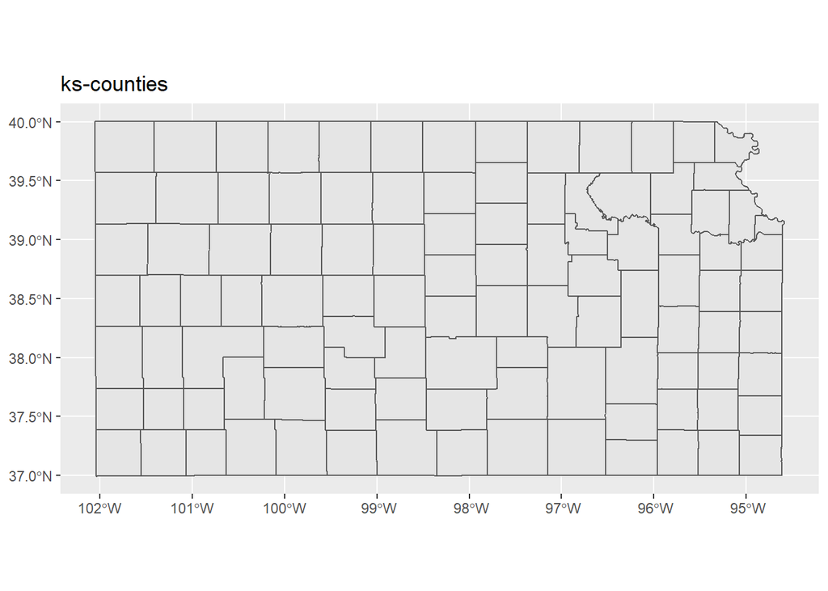

```r
all_counties                           %>%
   filter(STATEFP==20)                    %>%
   ggplot()                              +
      geom_sf(aes())                    +
      ggtitle("ks-counties")
```

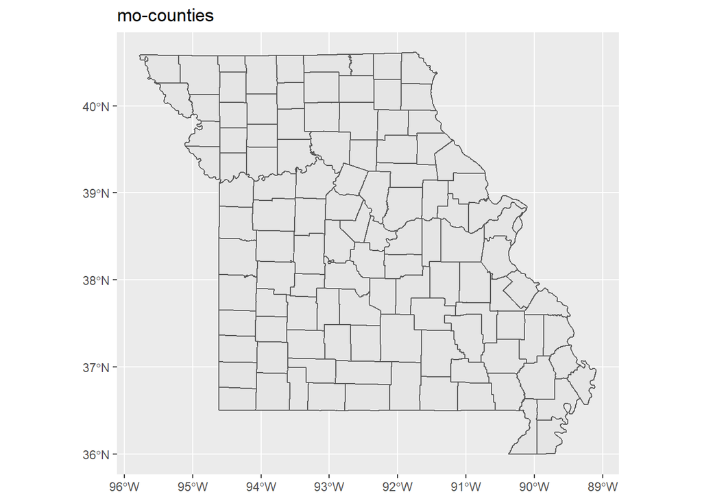

```r
all_counties                           %>%
   filter(STATEFP==29)                    %>%
   ggplot()                              +
      geom_sf(aes())                    +
      ggtitle("mo-counties")
```

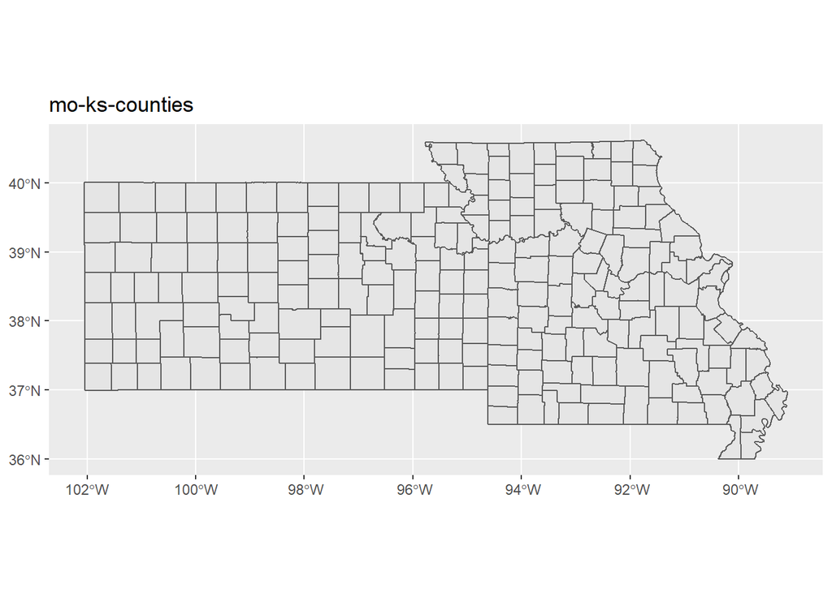

```r
all_counties                           %>%
   filter(STATEFP==20|STATEFP==29)     %>%
   ggplot()                              +
      geom_sf(aes())                    +
      ggtitle("mo-ks-counties")
```

### Community districts

This shapefile, Community_District, was provided by Neal Wilson. The various functions described in the US counties shapefiles section will be used here.

```r
file_name <- "Community_District.shp"
path_name                              %>%
  paste(file_name, sep="/")            %>%
  st_read(stringsAsFactors=FALSE)      -> Community_Districts
head(Community_Districts)
```

```
## Simple feature collection with 6 features and 8 fields
## Geometry type: POLYGON
## Dimension:     XYZ
## Bounding box:  xmin: 2758255 ymin: 1013899 xmax: 2821302 ymax: 1086876
## z_range:       zmin: 0 zmax: 0
## Projected CRS: NAD_1983_StatePlane_Missouri_West_FIPS_2403_Feet
##   State STATE_FIPS CD_ID
## 1    MO         29   106
## 2    MO         29   108
## 3    MO         29   113
## 4    MO         29   102
## 5    MO         29   129
## 6    MO         29   116
##                                                                                 shid
## 1            country:us/state:mo/place:kansas_city_city/community_district:east_side
```

[output cut: 19 more lines]

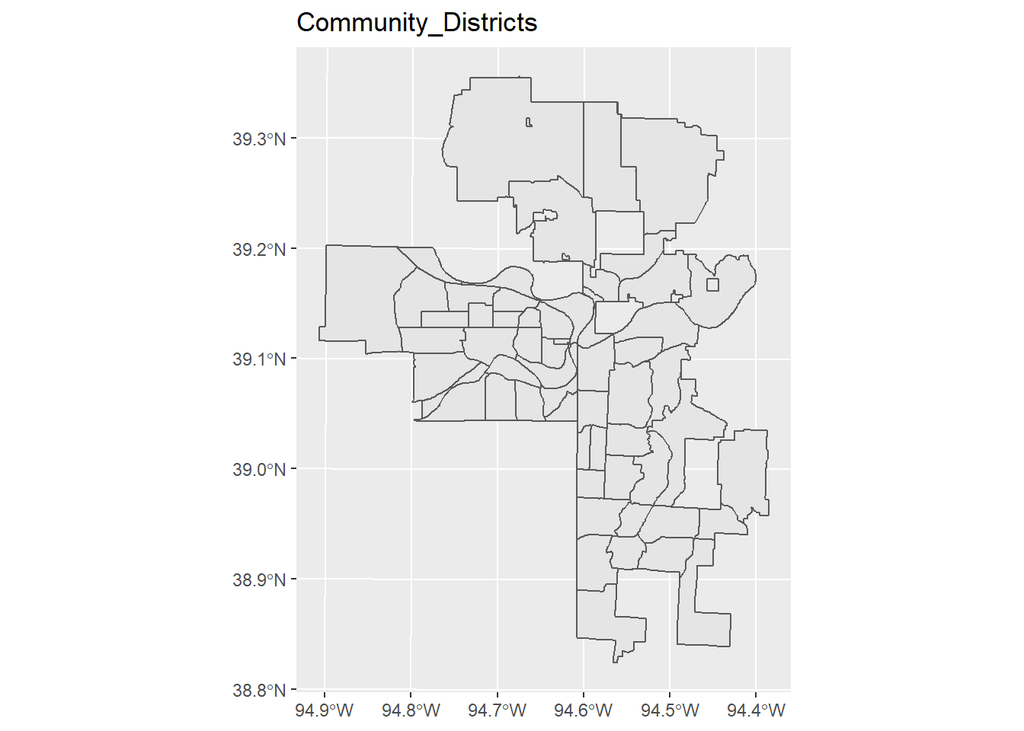

```r
Community_Districts                  %>%
  ggplot()                              +
      geom_sf(aes())                    +
      ggtitle("Community_Districts")
```

```r
Community_Districts %>%
  st_transform(crs=st_crs(all_counties)) -> cd
```

### Neighborhoods

This shapefile, Neighborhoods, was provided by Neal Wilson. The various functions described in the US counties shapefiles section will be used here.

```r
file_name <- "Neighborhoods.shp"
path_name                              %>%
  paste(file_name, sep="/")            %>%
  st_read(stringsAsFactors=FALSE)      -> Neighborhoods
head(Neighborhoods)
```

```
## Simple feature collection with 6 features and 10 fields
## Geometry type: MULTIPOLYGON
## Dimension:     XYZ
## Bounding box:  xmin: 2758295 ymin: 1025273 xmax: 2798010 ymax: 1097426
## z_range:       zmin: 0 zmax: 0
## Projected CRS: NAD_1983_StatePlane_Missouri_West_FIPS_2403_Feet
##   NID              AreaName nbr_id           CommunityD id label_long shid
## 1 244 Truman Sports Complex      1           Blue Ridge  0       <NA> <NA>
## 2 241              Area 241      2     Greater Downtown  0       <NA> <NA>
## 3 243            Swope Park      3           Swope Park  0       <NA> <NA>
## 4 245              Area 245      4 Northeast Industrial  0       <NA> <NA>
## 5 246              Area 246      5             Chouteau  0       <NA> <NA>
## 6 247      Downtown Airport      6     Downtown Airport  0       <NA> <NA>
##   Shape_Leng Shape_Le_1 Shape_Area                       geometry
## 1   22348.39   22348.39   25684112 MULTIPOLYGON Z (((2790938 1...
## 2    7813.00    7813.00    3582073 MULTIPOLYGON Z (((2770343 1...
## 3   47898.34   47898.34   68578786 MULTIPOLYGON Z (((2784236 1...
## 4   60205.57   60205.57  184656719 MULTIPOLYGON Z (((2790426 1...
## 5   28368.39   28368.39   40242276 MULTIPOLYGON Z (((2791398 1...
## 6   54946.27   54946.27   57490375 MULTIPOLYGON Z (((2763269 1...
```

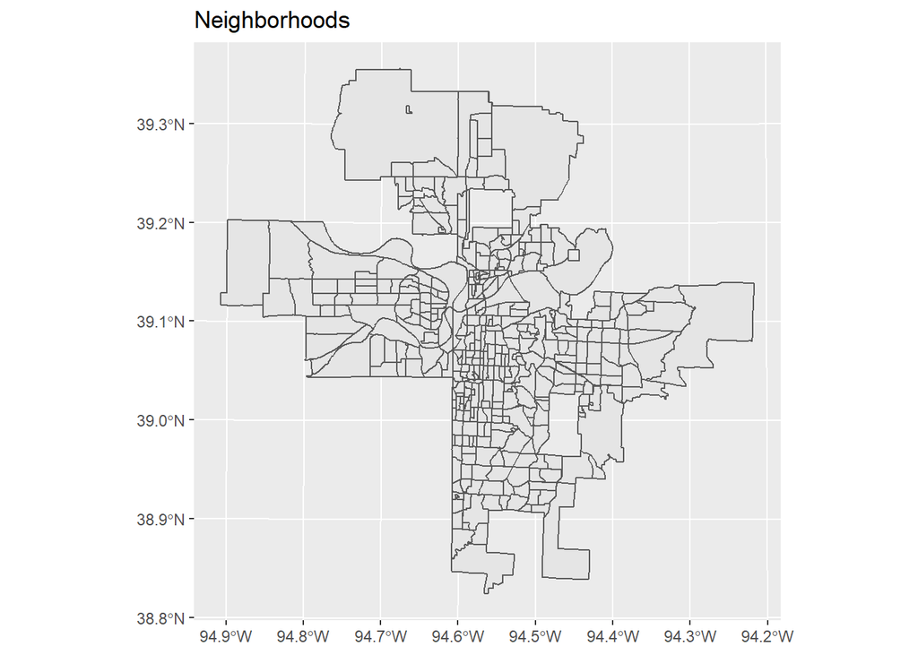

```r
Neighborhoods                          %>%
  ggplot()                              +
      geom_sf(aes())                    +
      ggtitle("Neighborhoods")
```

```r
Neighborhoods                          %>%
  st_transform(crs=st_crs(all_counties)) -> nbd
```

### Calculate intersections

#### Intersection of counties with community districts

It is important that both the counties and the community districts use a common coordinate reference system. It is uncelar WHICH coordinate reference system is best, but this is controlled by the st_crs function of the sf package.

The st_intersects function will evaluate to TRUE if two shapefiles intersect. The st_area function will give the area of a shapefile and the st_intersection function will produce a new shapefile from the intersection of two shapefiles.

```r
all_counties                         %>%
  filter(STATEFP==20 | STATEFP==29)  ->       ks_mo_counties
ks_mo_counties                       %>%
  filter(STATEFP==29 & COUNTYFP=="095")               %>%
  st_intersects( cd, sparse=FALSE) -> intersect_matrix
```

```
## st_as_s2(): dropping Z and/or M coordinate
```

```r
 print(intersect_matrix)
```

```
##      [,1] [,2] [,3] [,4] [,5] [,6] [,7] [,8] [,9] [,10] [,11] [,12] [,13] [,14]
## [1,] TRUE TRUE TRUE TRUE TRUE TRUE TRUE TRUE TRUE  TRUE  TRUE  TRUE  TRUE  TRUE
##      [,15] [,16] [,17] [,18] [,19] [,20] [,21] [,22] [,23] [,24] [,25] [,26]
## [1,]  TRUE  TRUE  TRUE FALSE FALSE  TRUE FALSE  TRUE FALSE  TRUE  TRUE  TRUE
##      [,27] [,28] [,29] [,30] [,31] [,32] [,33] [,34] [,35] [,36] [,37] [,38]
## [1,]  TRUE  TRUE  TRUE  TRUE FALSE FALSE FALSE FALSE FALSE FALSE FALSE FALSE
##      [,39] [,40] [,41] [,42] [,43] [,44] [,45] [,46] [,47] [,48] [,49] [,50]
## [1,] FALSE FALSE FALSE FALSE FALSE FALSE FALSE FALSE FALSE FALSE FALSE FALSE
##      [,51] [,52] [,53] [,54] [,55] [,56] [,57] [,58] [,59]
## [1,] FALSE  TRUE  TRUE  TRUE FALSE FALSE FALSE FALSE FALSE
```

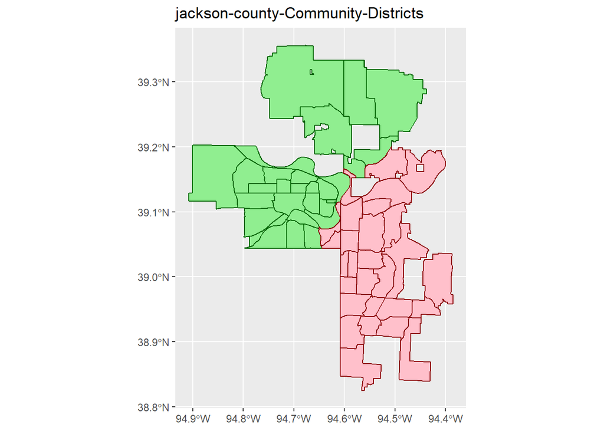

```r
 ggplot(data=cd, aes()) +
        geom_sf(fill="lightgreen", col="darkgreen") +
        geom_sf(data=cd[intersect_matrix, ], fill="pink", col="darkred") +
        ggtitle("jackson-county-Community-Districts")
```

```r
total_area  <- st_area(cd[intersect_matrix,]) / 1000000
```

```
## st_as_s2(): dropping Z and/or M coordinate
```

```r
total_area
```

```
## Units: [m^2]
##  [1] 26.153155 10.976557 16.888662 20.130732 38.311285 24.534575  6.548699
##  [8] 35.453686 13.005342  7.076443 11.110385 13.932340 18.616027  7.847738
## [15]  5.354837 15.605982 30.803882 35.784092 25.326542 11.864719 17.728644
## [22]  8.066949 16.738061 10.350375 29.862824 19.362663  6.804830  1.611053
## [29]  6.026108
```

```r
ks_mo_counties  %>%
  filter(STATEFP==29 & COUNTYFP=="095")  -> jackson_county
intersect_area <- st_area(st_intersection(cd[intersect_matrix,],jackson_county)) / 1000000
```

```
## st_as_s2(): dropping Z and/or M coordinate
```

```r
intersect_area
```

```
## Units: [m^2]
##  [1] 26.153155092 10.976556694 16.835089407 20.130731900 38.311285313
##  [6] 24.122240870  0.045191130 35.453686017 13.005341895  7.076442578
## [11] 11.109888442 13.932339522 18.616027054  7.847362301  5.354506614
## [16] 15.605982421 30.794016602  0.246528126  0.004530085 11.864718918
## [21] 17.728643717  8.066949386 16.735851096 10.350375426 27.118170294
## [26] 19.356297224  0.012130833  0.015091484  0.004254228
```

```r
pct_area  <- round(intersect_area/total_area * 100, 1)
pct_area
```

```
## Units: [1]
##  [1] 100.0 100.0  99.7 100.0 100.0  98.3   0.7 100.0 100.0 100.0 100.0 100.0
## [13] 100.0 100.0 100.0 100.0 100.0   0.7   0.0 100.0 100.0 100.0 100.0 100.0
## [25]  90.8 100.0   0.2   0.9   0.1
```

```r
st_centroid(cd[intersect_matrix,])
```

```
## st_as_s2(): dropping Z and/or M coordinate
```

```
## Simple feature collection with 29 features and 8 fields
## Geometry type: POINT
## Dimension:     XY
## Bounding box:  xmin: -94.63104 ymin: 38.86295 xmax: -94.41391 ymax: 39.17071
## Geodetic CRS:  NAD83
## First 10 features:
##    State STATE_FIPS CD_ID
## 1     MO         29   106
## 2     MO         29   108
## 3     MO         29   113
## 4     MO         29   102
## 5     MO         29   129
## 6     MO         29   116
## 7     MO         29   114
## 8     MO         29   101
```

[output cut: 35 more lines]

```r
cd[1,]
```

```
## Simple feature collection with 1 feature and 8 fields
## Geometry type: POLYGON
## Dimension:     XYZ
## Bounding box:  xmin: -94.57293 ymin: 39.03761 xmax: -94.5199 ymax: 39.09808
## z_range:       zmin: 0 zmax: 0
## Geodetic CRS:  NAD83
##   State STATE_FIPS CD_ID
## 1    MO         29   106
##                                                                      shid
## 1 country:us/state:mo/place:kansas_city_city/community_district:east_side
##     CD_NAME      NAME Shape_Area Shape_Leng                       geometry
## 1 East Side East Side  281713946   71542.21 POLYGON Z ((-94.52337 39.09...
```

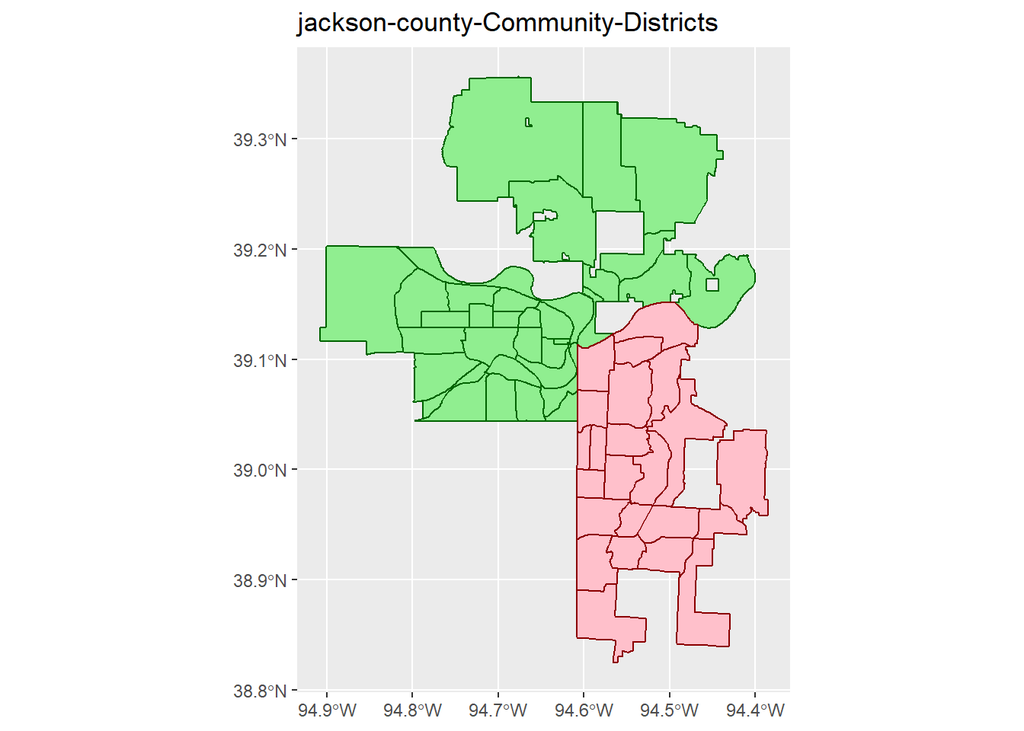

```r
 ggplot(data=cd, aes()) +
        geom_sf(fill="lightgreen", col="darkgreen") +
        geom_sf(data=cd[intersect_matrix,][as.numeric(pct_area)>10,], fill="pink", col="darkred") +
        ggtitle("jackson-county-Community-Districts")
```